## Aprendizado de Máquina I

### Hugo Tremonte de Carvalho

#### `hugo@dme.ufrj.br`

# K-médias

## Análise de agrupamento

- Conjunto de observações $\{\mathbf{x}_1, \dots, \mathbf{x}_n\} \subset \mathbb{R}^p$
- Encontrar grupos de observações similares
- *Quantos* grupos? O que são observações *similares*?

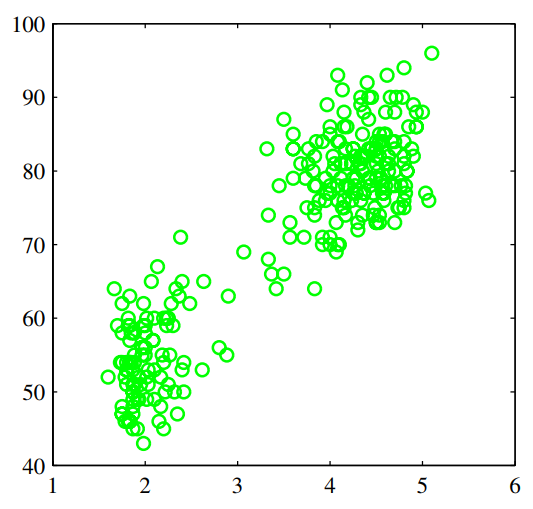

(Figura A.5 de *Pattern Recognition and Machine Learning*, por C. Bishop) Duração de uma erupção (min) e tempo para a próxima erupção (min) do gêiser *Old Faithful* no Parque Nacional de Yellowstone.

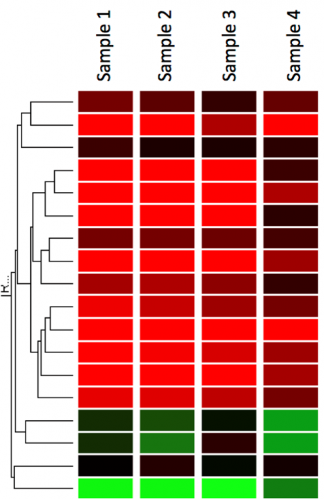

(Figura retirada de `https://www.ebi.ac.uk/`) Genes agrupados pelo seu padrão de expressão.

## Agrupamento por $K$-médias

- Agrupar $n$ observações em $\mathbb{R}^p$ em $K$ grupos distintos e sem interseção
- $K$ escolhido pelo usuário $\implies$ “verdade” desconhecida!

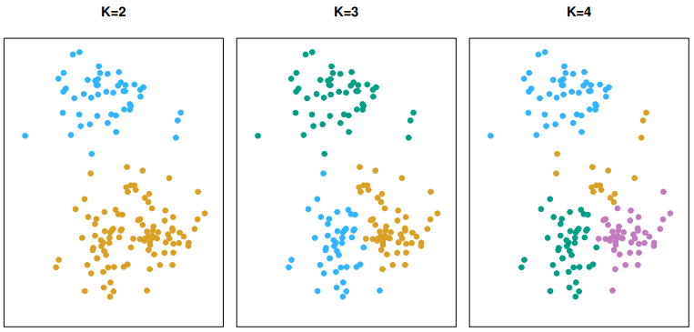

(Figura 10.5 de [ITSL]) Conjunto de dados artificial agrupado com distintos valores de $K$.

## Formulação

- $C_1, \dots, C_K$: conjuntos de índices referentes a cada grupo, satisfazendo:
  - $C_1 \cup \dots \cup C_K = \{1, \dots, n\}$
  - $C_k \cap C_{k'} = \emptyset$, se $k \neq k'$
- $\mathbf{x}_i$ no grupo $k$ se e somente se $i \in C_k$
- “Bom” agrupament $\Rightarrow$ *Menor variabilidade intra-grupo*:
  $$W(C_k) = \frac{1}{|C_k|} \sum_{i, i' \in C_k} \|\mathbf{x}_i - \mathbf{x}_{i'}\|^2$$
  - Distância quadrática média entre os elementos do grupo $k$
- Agrupamento *via* $K$-médias: solução do problema de otimização
  $$\min_{C_1, \dots, C_K} \sum_{k = 1}^{K} W(C_k) = \min_{C_1, \dots, C_K} \sum_{k = 1}^{K} \frac{1}{|C_k|} \sum_{i, i' \in C_k} \|\mathbf{x}_i - \mathbf{x}_{i'}\|^2$$

## Algoritmo

- Muito fácil resolver
  $$\min_{C_1, \dots, C_K} \sum_{k = 1}^{K} \frac{1}{|C_k|} \sum_{i, i' \in C_k} \|\mathbf{x}_i - \mathbf{x}_{i'}\|^2$$
- Basta considerar todos os agrupamentos!
- Obviamente, inviável
- Algoritmo para encontrar um ótimo local:
  1. Rotule aleatoriamente de 1 até $K$ cada observação
  2. Enquanto houverem alterações no agrupamento, repita:
  1. Para um dos $K$ grupos, calcule o seu centroide (média)
  2. Associe cada observação ao grupo cujo centroide é o mais próximo (na norma $\ell^2)$
- Resultado final pode depender da alocação inicial $\implies$ rodar diversas vezes, se possível

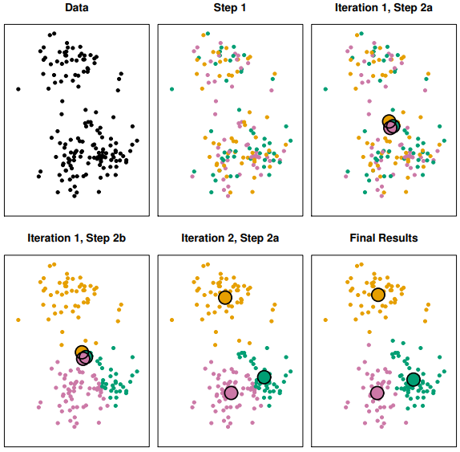

(Figura 10.6 de [ITSL]) Dez iterações do algoritmo de agrupamento por $K$-médias, com $K = 3$.

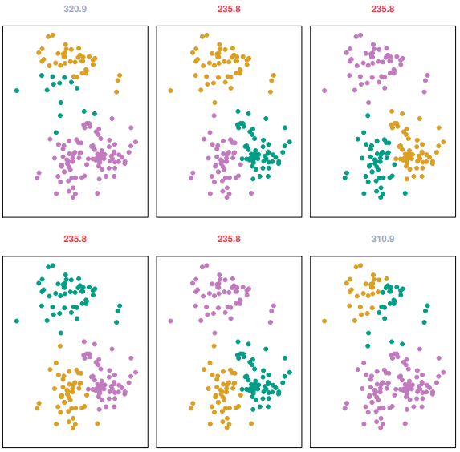

(Figura 10.7 de [ITSL]) Seis rodadas do algoritmo de agrupamento por $K$-médias com os respectivos valores das funções objetivo. Em vermelho, o menor valor alcançado.

## Algumas perguntas

- Como escolher $K$?
- O que acontece se:
  - $n \gg 1$?
  - $K \gg 1$?
  - $p \gg 1$?